# Analysis of variance for Rgronomists

2018/02/24

## Before we dig into rstats

## What we will do today

1. Import data
2. Tidying and transforming data
3. Visualise data
4. Model estimation
5. Diagnosis checking

## What is ANOVA ?

[figure not shown]

## Another example…

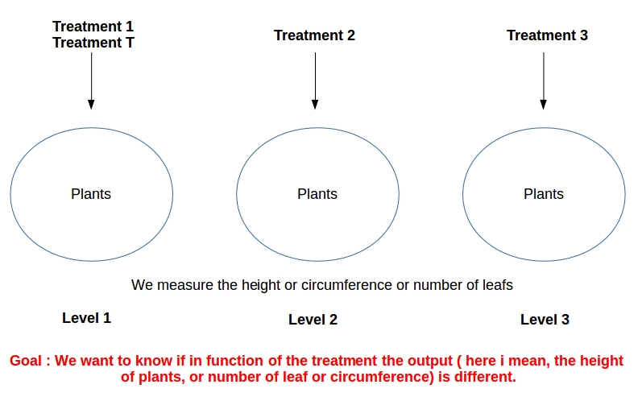

## Keypoints

- What is your goal ?
- What objective do you want to achieve with this analysis ?
- Ask yourself if this analysis is the best way to reach your goal ?
- What is your experimental design ?

## Understand your data

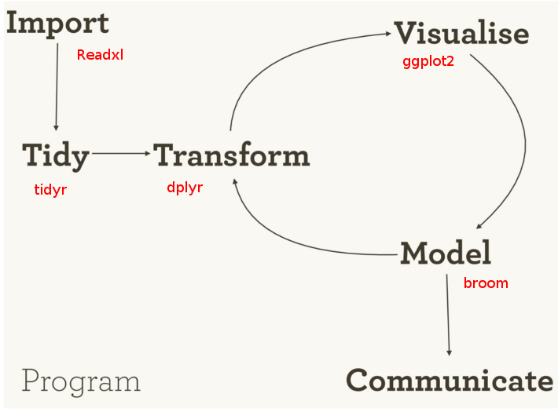

## Import data

## Importing from Excel sheet

- Our dataset is in .xlsx format so we will use the `readxl` package.

```r
library(readxl)
dataset <- read_excel("dataset.xlsx")
View(dataset) # or dataset
```

## Importing from Excel sheet

```
## # A tibble: 1,680 x 5
##    bloc  sem   trait  HAUT NBFEUIL
##    <chr> <chr> <chr> <dbl>   <dbl>
##  1 B1    S3    TEM    14.0    4.00
##  2 B1    S3    TEM    15.0    3.00
##  3 B1    S3    TEM    15.0    4.00
##  4 B1    S3    TEM    15.0    3.00
##  5 B1    S3    TEM    14.0    4.00
##  6 B1    S3    TEM    11.0    4.00
##  7 B1    S3    TEM    15.0    4.00
##  8 B1    S3    TEM    14.0    4.00
##  9 B1    S3    TEM    16.0    4.00
## 10 B1    S3    TEM    14.0    3.00
## # ... with 1,670 more rows
```

## Tidying and transforming data

## What is a tidy dataset ?

From Hadley Wickham, a dataset is tidy when :

- Each variable must have its own column.
- Each observation must have its own row.
- Each value must have its own cell.

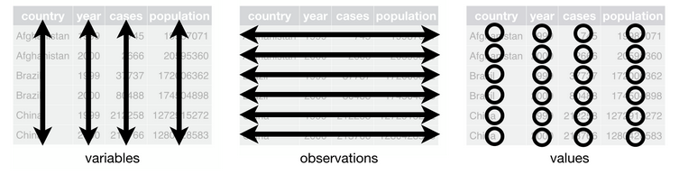

## Linear models reminder : stochastic linear model

\[ Y_{ij}=\beta_0+\beta_iX_{i}+\epsilon_{ij},~~~ i = 1,...,n;~~~ j = 1, ..., k\]

- Y is the dependant variable: the variable we study.
- X is the independant variable: the variable controlled by the experimenter.
- Epsilon is the error.
- Beta is the general mean.

## Transforming data

- We'll use the package `dplyr` for the purpose of transforming our data.

```r
library(tidyverse)
first_anova <- dataset %>%
  select(bloc,trait, HAUT) %>%
  group_by(trait)
```

- By this operation we have selected `the variables` (columns) bloc, trait and HAUT, and group values by 'trait'.
- Now we can do the anova analysing the height of plants varying by treatment.

## Initial inspection

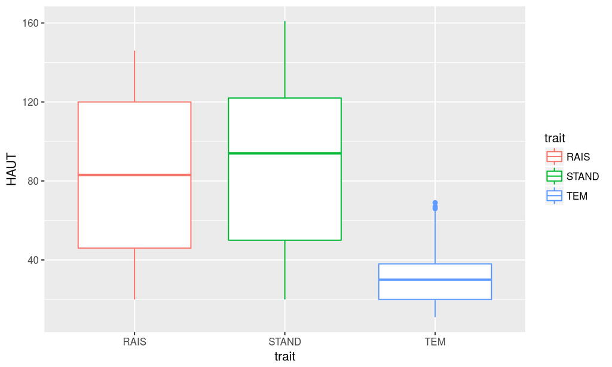

```r
ggplot(data = first_anova) +
  geom_boxplot(mapping = aes(x = trait, y = HAUT, color = trait))
```

## Estimate the model

## Estimate the model

```r
library(broom)
model_1 <- aov(HAUT ~ trait + bloc, first_anova)
tidy_model <- tidy(model_1)
tidy_model
```

```
##        term   df     sumsq    meansq statistic    p.value
## 1     trait    2 1086727.5 543363.75 516.42468 2.046e-175
## 2      bloc    3     109.7     36.57   0.03476  9.913e-01
## 3 Residuals 1674 1761323.5   1052.16        NA         NA
```

## Estimate the model

```r
head(augment(model_1))
```

```
##   HAUT trait bloc .fitted .se.fit .resid     .hat .sigma   .cooksd
## 1   14   TEM   B1   30.38   1.938 -16.38 0.003571  32.44 0.0001529
## 2   15   TEM   B1   30.38   1.938 -15.38 0.003571  32.44 0.0001348
## 3   15   TEM   B1   30.38   1.938 -15.38 0.003571  32.44 0.0001348
## 4   15   TEM   B1   30.38   1.938 -15.38 0.003571  32.44 0.0001348
## 5   14   TEM   B1   30.38   1.938 -16.38 0.003571  32.44 0.0001529
## 6   11   TEM   B1   30.38   1.938 -19.38 0.003571  32.44 0.0002140
##   .std.resid
## 1    -0.5059
## 2    -0.4750
## 3    -0.4750
## 4    -0.4750
## 5    -0.5059
## 6    -0.5986
```

## Estimate the model

```r
glance(model_1)
```

```
##   r.squared adj.r.squared sigma statistic   p.value df logLik   AIC   BIC
## 1    0.3816        0.3797 32.44     206.6 8.55e-172  6  -8226 16466 16504
##   deviance df.residual
## 1  1761323        1674
```

## Multiple comparisons of mean

```r
library(agricolae)
snk_test <- SNK.test(model_1, "trait")
```

## Multiple comparisons of mean

```
## $statistics
##   MSerror   Df  Mean    CV
##      1052 1674 66.27 48.95
##
## $parameters
##   test name.t ntr alpha
##    SNK  trait   3  0.05
##
## $snk
##   Table CriticalRange
## 2 2.774         3.802
## 3 3.317         4.547
##
## $means
##        HAUT   std   r Min Max Q25 Q50 Q75
## RAIS  81.78 39.08 560  20 146  46  83 120
## STAND 86.62 38.77 560  20 161  50  94 122
## TEM   30.41 10.96 560  11  69  20  30  38
##
## $comparison
## NULL
##
## $groups
##        HAUT groups
## STAND 86.62      a
## RAIS  81.78      b
## TEM   30.41      c
##
## attr(,"class")
## [1] "group"
```

## A beautiful graph to finish the analysis

- Generate the table

```r
by_trait_sem <- dataset %>%
  select(sem,trait,HAUT) %>%
  group_by(trait, sem)

table_graph <- summarise(by_trait_sem,
               count = n(),
               Hauteur = mean(HAUT, na.rm = TRUE),
               sd = sd(HAUT, na.rm = TRUE),
               se = sd / sqrt(count)
               )
```

## A beautiful graph to finish analysis

```r
table_graph
```

```
## # A tibble: 30 x 6
## # Groups:   trait [?]
##    trait sem   count Hauteur    sd    se
##    <chr> <chr> <int>   <dbl> <dbl> <dbl>
##  1 RAIS  S10      56   120    2.93 0.391
##  2 RAIS  S11      56   130    3.70 0.495
##  3 RAIS  S12      56   134    6.03 0.806
##  4 RAIS  S3       56    22.6  1.92 0.257
##  5 RAIS  S4       56    33.4  3.07 0.410
##  6 RAIS  S5       56    46.7  3.11 0.415
##  7 RAIS  S6       56    57.9  5.33 0.712
##  8 RAIS  S7       56    71.6  2.93 0.391
##  9 RAIS  S8       56    93.3  3.95 0.528
## 10 RAIS  S9       56   108    4.39 0.587
## # ... with 20 more rows
```

## Graph

```r
graph <- ggplot(data = table_graph,
                aes(x = sem, y = Hauteur, colour = trait)) +
  geom_line() +
  geom_point() +
  geom_errorbar(aes(ymax = Hauteur + se,
                    ymin = Hauteur - se)
                , width = .25) +
  labs(x = "Nombre de semaines"
       , y = "Hauteur des plantes") +
  scale_x_discrete(limits = c("S3","S4","S5", "S6","S7"
                              ,"S8", "S9", "S10", "S11", "S12")
                   )
```

## Graph

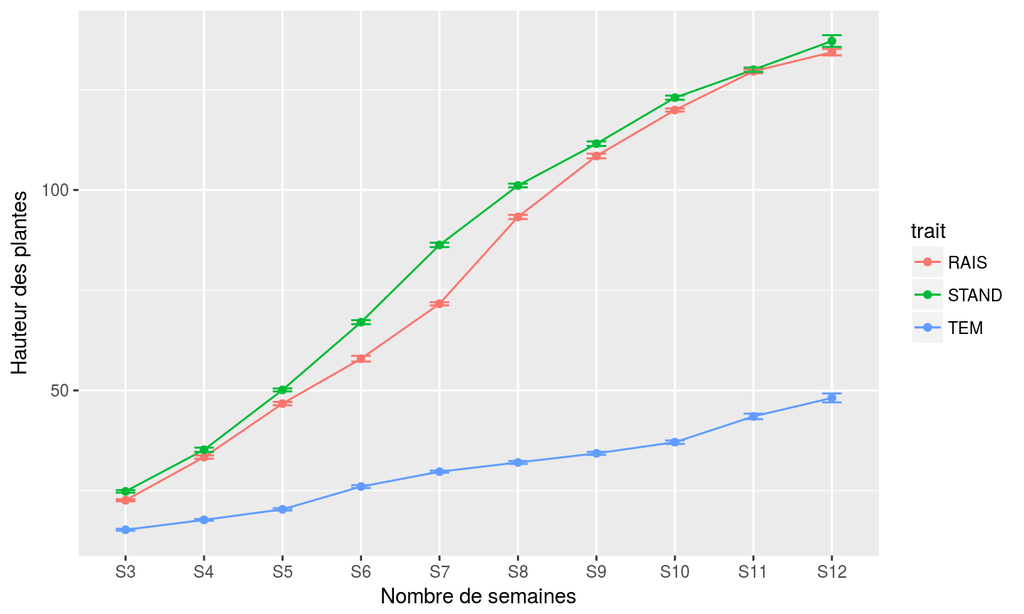

## Any Questions ?

[figure not shown]

## Your turn

Let's Go !!!

[figure not shown]